# Predict Bike Sharing Demand with AutoGluon Template

## Project: Predict Bike Sharing Demand with AutoGluon

This notebook is a template with each step that you need to complete for the project.

Please fill in your code where there are explicit `?` markers in the notebook. You are welcome to add more cells and code as you see fit.

Once you have completed all the code implementations, please export your notebook as a HTML file so the reviews can view your code. Make sure you have all outputs correctly outputted.

`File-> Export Notebook As... -> Export Notebook as HTML`

There is a writeup to complete as well after all code implememtation is done. Please answer all questions and attach the necessary tables and charts. You can complete the writeup in either markdown or PDF.

Completing the code template and writeup template will cover all of the rubric points for this project.

The rubric contains "Stand Out Suggestions" for enhancing the project beyond the minimum requirements. The stand out suggestions are optional. If you decide to pursue the "stand out suggestions", you can include the code in this notebook and also discuss the results in the writeup file.

## Step 1: Create an account with Kaggle

### Create Kaggle Account and download API key

Below is example of steps to get the API username and key. Each student will have their own username and key.

1. Open account settings.

2. Scroll down to API and click Create New API Token.

3. Open up `kaggle.json` and use the username and key.


## Step 2: Download the Kaggle dataset using the kaggle python library

### Open up Sagemaker Studio and use starter template

1. Notebook should be using a `ml.t3.medium` instance (2 vCPU + 4 GiB)
2. Notebook should be using kernal: `Python 3 (MXNet 1.8 Python 3.7 CPU Optimized)`

### Install packages

```python
Clone git repository
#git clone https://github.com/scinar03/cd0385-project-starter.git
```

```python
!pip install -U pip
!pip install -U setuptools wheel
!pip install -U "mxnet<2.0.0" bokeh==2.0.1
!pip install autogluon --no-cache-dir
# Without --no-cache-dir, smaller aws instances may have trouble installing
```

```python
pip install kaggle
```

### Setup Kaggle API Key

```python
!touch /root/.kaggle/kaggle.json
```

```python
# create the .kaggle directory and an empty kaggle.json file
!mkdir -p /root/.kaggle
!touch /root/.kaggle/kaggle.json
!chmod 600 /root/.kaggle/kaggle.json
```

```python
import os
print(os.getcwd())
```

```
C:\Python\projects\cd0385-project-starter\project
```

```python
# Fill in your user name and key from creating the kaggle account and API token file
import json
kaggle_username = "ivanperfilyev"
kaggle_key = "c0dc860e72e6aeeb1251839d92d98547"

# Save API token the kaggle.json file
with open("/root/.kaggle/kaggle.json", "w") as f:
    f.write(json.dumps({"username": kaggle_username, "key": kaggle_key}))
print('done')
kaggle_username
```

```
done
```

```
'ivanperfilyev'
```

### Download and explore dataset

### Go to the bike sharing demand competition and agree to the terms

```python
import kaggle
import sys
from sys import exit

#!kaggle competitions download -c bike-sharing-demand

# Download the dataset, it will be in a .zip file so you'll need to unzip it as well.
#!kaggle competitions download -c bike-sharing-demand
# If you already downloaded it you can use the -o command to overwrite the file
print('done')
```

```
done
```

```python
import zipfile
import os

# Specify the path to the zip file
zip_file_path = 'bike-sharing-demand.zip'
extract_folder = 'bike-sharing-demand'  # Folder to extract to

# Create a directory to extract to
os.makedirs(extract_folder, exist_ok=True)

# Unzip the file
with zipfile.ZipFile(zip_file_path, 'r') as zip_ref:
    zip_ref.extractall(extract_folder)

print("Unzipping completed!")
```

```
Unzipping completed!
```

```python
import pandas as pd
from autogluon.tabular import TabularPredictor
import autogluon as ag
```

```python
# Create the train dataset in pandas by reading the csv
# Set the parsing of the datetime column so you can use some of the `dt` features in pandas later
import os
print(os.getcwd())
train = pd.read_csv('./bike-sharing-demand/train.csv')
train.info()
train.head()
```

```
C:\Python\projects\cd0385-project-starter\project
<class 'pandas.core.frame.DataFrame'>
RangeIndex: 10886 entries, 0 to 10885
Data columns (total 12 columns):
 #   Column      Non-Null Count  Dtype
---  ------      --------------  -----
 0   datetime    10886 non-null  object
 1   season      10886 non-null  int64
 2   holiday     10886 non-null  int64
 3   workingday  10886 non-null  int64
 4   weather     10886 non-null  int64
 5   temp        10886 non-null  float64
 6   atemp       10886 non-null  float64
 7   humidity    10886 non-null  int64
 8   windspeed   10886 non-null  float64
 9   casual      10886 non-null  int64
 10  registered  10886 non-null  int64
 11  count       10886 non-null  int64
dtypes: float64(3), int64(8), object(1)
memory usage: 1020.7+ KB
```

|  | datetime | season | holiday | workingday | weather | temp | atemp | humidity | windspeed | casual | registered | count |
| --- | --- | --- | --- | --- | --- | --- | --- | --- | --- | --- | --- | --- |
| 0 | 2011-01-01 00:00:00 | 1 | 0 | 0 | 1 | 9.84 | 14.395 | 81 | 0.0 | 3 | 13 | 16 |
| 1 | 2011-01-01 01:00:00 | 1 | 0 | 0 | 1 | 9.02 | 13.635 | 80 | 0.0 | 8 | 32 | 40 |
| 2 | 2011-01-01 02:00:00 | 1 | 0 | 0 | 1 | 9.02 | 13.635 | 80 | 0.0 | 5 | 27 | 32 |
| 3 | 2011-01-01 03:00:00 | 1 | 0 | 0 | 1 | 9.84 | 14.395 | 75 | 0.0 | 3 | 10 | 13 |
| 4 | 2011-01-01 04:00:00 | 1 | 0 | 0 | 1 | 9.84 | 14.395 | 75 | 0.0 | 0 | 1 | 1 |

```python
# Simple output of the train dataset to view some of the min/max/varition of the dataset features.
train.describe()
```

|  | season | holiday | workingday | weather | temp | atemp | humidity | windspeed | casual | registered | count |
| --- | --- | --- | --- | --- | --- | --- | --- | --- | --- | --- | --- |
| count | 10886.000000 | 10886.000000 | 10886.000000 | 10886.000000 | 10886.00000 | 10886.000000 | 10886.000000 | 10886.000000 | 10886.000000 | 10886.000000 | 10886.000000 |
| mean | 2.506614 | 0.028569 | 0.680875 | 1.418427 | 20.23086 | 23.655084 | 61.886460 | 12.799395 | 36.021955 | 155.552177 | 191.574132 |
| std | 1.116174 | 0.166599 | 0.466159 | 0.633839 | 7.79159 | 8.474601 | 19.245033 | 8.164537 | 49.960477 | 151.039033 | 181.144454 |
| min | 1.000000 | 0.000000 | 0.000000 | 1.000000 | 0.82000 | 0.760000 | 0.000000 | 0.000000 | 0.000000 | 0.000000 | 1.000000 |
| 25% | 2.000000 | 0.000000 | 0.000000 | 1.000000 | 13.94000 | 16.665000 | 47.000000 | 7.001500 | 4.000000 | 36.000000 | 42.000000 |
| 50% | 3.000000 | 0.000000 | 1.000000 | 1.000000 | 20.50000 | 24.240000 | 62.000000 | 12.998000 | 17.000000 | 118.000000 | 145.000000 |
| 75% | 4.000000 | 0.000000 | 1.000000 | 2.000000 | 26.24000 | 31.060000 | 77.000000 | 16.997900 | 49.000000 | 222.000000 | 284.000000 |
| max | 4.000000 | 1.000000 | 1.000000 | 4.000000 | 41.00000 | 45.455000 | 100.000000 | 56.996900 | 367.000000 | 886.000000 | 977.000000 |

```python
# Create the test pandas dataframe in pandas by reading the csv, remember to parse the datetime!
test = pd.read_csv('./bike-sharing-demand/test.csv')
test.head()
```

|  | datetime | season | holiday | workingday | weather | temp | atemp | humidity | windspeed |
| --- | --- | --- | --- | --- | --- | --- | --- | --- | --- |
| 0 | 2011-01-20 00:00:00 | 1 | 0 | 1 | 1 | 10.66 | 11.365 | 56 | 26.0027 |
| 1 | 2011-01-20 01:00:00 | 1 | 0 | 1 | 1 | 10.66 | 13.635 | 56 | 0.0000 |
| 2 | 2011-01-20 02:00:00 | 1 | 0 | 1 | 1 | 10.66 | 13.635 | 56 | 0.0000 |
| 3 | 2011-01-20 03:00:00 | 1 | 0 | 1 | 1 | 10.66 | 12.880 | 56 | 11.0014 |
| 4 | 2011-01-20 04:00:00 | 1 | 0 | 1 | 1 | 10.66 | 12.880 | 56 | 11.0014 |

```python
# Same thing as train and test dataset
submission = pd.read_csv('./bike-sharing-demand/sampleSubmission.csv')
submission.head()
```

|  | datetime | count |
| --- | --- | --- |
| 0 | 2011-01-20 00:00:00 | 0 |
| 1 | 2011-01-20 01:00:00 | 0 |
| 2 | 2011-01-20 02:00:00 | 0 |
| 3 | 2011-01-20 03:00:00 | 0 |
| 4 | 2011-01-20 04:00:00 | 0 |

## Step 3: Train a model using AutoGluon’s Tabular Prediction

Requirements:

- We are prediting `count`, so it is the label we are setting.
- Ignore `casual` and `registered` columns as they are also not present in the test dataset.
- Use the `root_mean_squared_error` as the metric to use for evaluation.
- Set a time limit of 10 minutes (600 seconds).
- Use the preset `best_quality` to focus on creating the best model.

```python
#Drop casual and registered:
for_delete = ['casual','registered']
train.drop(for_delete, axis = 1, inplace = True)
```

```python
predictor = TabularPredictor(label="count", problem_type='regression',
                             eval_metric = 'root_mean_squared_error').fit(train_data=train , time_limit=600,
                                                                          presets="best_quality"
                                               )
```

[output not shown]

[output cut: 33 more lines]

[output not shown]

[output not shown]

```
(_dystack pid=24900) 	-131.9758	 = Validation score   (-root_mean_squared_error)
(_dystack pid=24900) 	54.99s	 = Training   runtime
(_dystack pid=24900) 	14.86s	 = Validation runtime
(_dystack pid=24900) Fitting model: LightGBM_BAG_L1 ... Training model for up to 12.44s of the 58.34s of remaining time.
(_dystack pid=24900) 	Fitting 8 child models (S1F1 - S1F8) | Fitting with ParallelLocalFoldFittingStrategy (8 workers, per: cpus=1, gpus=0, memory=0.68%)
```

```
(_ray_fit pid=15628) [1000]	valid_set's rmse: 135.098 [repeated 3x across cluster]
```

```
(_ray_fit pid=31944) 	Ran out of time, early stopping on iteration 1796. Best iteration is:
(_ray_fit pid=31944) 	[1448]	valid_set's rmse: 128.885
(_dystack pid=24900) 	-131.8496	 = Validation score   (-root_mean_squared_error)
(_dystack pid=24900) 	12.12s	 = Training   runtime
(_dystack pid=24900) 	1.88s	 = Validation runtime
(_dystack pid=24900) Fitting model: WeightedEnsemble_L2 ... Training model for up to 137.69s of the 36.01s of remaining time.
(_dystack pid=24900) 	Ensemble Weights: {'KNeighborsDist_BAG_L1': 1.0}
(_dystack pid=24900) 	-89.9155	 = Validation score   (-root_mean_squared_error)
(_dystack pid=24900) 	0.05s	 = Training   runtime
(_dystack pid=24900) 	0.0s	 = Validation runtime
(_dystack pid=24900) Fitting 106 L2 models, fit_strategy="sequential" ...
(_dystack pid=24900) Fitting model: LightGBMXT_BAG_L2 ... Training model for up to 35.94s of the 35.85s of remaining time.
(_dystack pid=24900) 	Fitting 8 child models (S1F1 - S1F8) | Fitting with ParallelLocalFoldFittingStrategy (8 workers, per: cpus=1, gpus=0, memory=0.49%)
```

```
(_ray_fit pid=15468) [1000]	valid_set's rmse: 70.5509 [repeated 7x across cluster]
(_ray_fit pid=22812) [2000]	valid_set's rmse: 74.8019 [repeated 8x across cluster]
```

[output not shown]

[output cut: 98 more lines]

```
	-53.4134	 = Validation score   (-root_mean_squared_error)
	25.13s	 = Training   runtime
	1.46s	 = Validation runtime
Fitting model: CatBoost_BAG_L2 ... Training model for up to 29.77s of the 29.60s of remaining time.
	Fitting 8 child models (S1F1 - S1F8) | Fitting with ParallelLocalFoldFittingStrategy (8 workers, per: cpus=1, gpus=0, memory=0.39%)
	-57.5376	 = Validation score   (-root_mean_squared_error)
	25.01s	 = Training   runtime
	0.79s	 = Validation runtime
Fitting model: WeightedEnsemble_L3 ... Training model for up to 360.00s of the -8.46s of remaining time.
	Ensemble Weights: {'RandomForestMSE_BAG_L2': 0.688, 'LightGBM_BAG_L2': 0.312}
	-53.0579	 = Validation score   (-root_mean_squared_error)
	0.19s	 = Training   runtime
	0.01s	 = Validation runtime
AutoGluon training complete, total runtime = 440.31s ... Best model: WeightedEnsemble_L3 | Estimated inference throughput: 63.1 rows/s (1361 batch size)
TabularPredictor saved. To load, use: predictor = TabularPredictor.load("C:\Python\projects\cd0385-project-starter\project\AutogluonModels\ag-20250317_224716")
```

### Review AutoGluon's training run with ranking of models that did the best.

```python
predictor.fit_summary()
```

```
*** Summary of fit() ***
Estimated performance of each model:
                     model   score_val              eval_metric  pred_time_val    fit_time  pred_time_val_marginal  fit_time_marginal  stack_level  can_infer  fit_order
0      WeightedEnsemble_L3  -53.057886  root_mean_squared_error      24.391116  288.660384                0.008142           0.186612            3       True         14
1   RandomForestMSE_BAG_L2  -53.413385  root_mean_squared_error      23.934190  281.842909                1.457307          25.131229            2       True         12
2          LightGBM_BAG_L2  -54.766575  root_mean_squared_error      22.925667  263.342544                0.448784           6.630863            2       True         11
3          CatBoost_BAG_L2  -57.537563  root_mean_squared_error      23.263744  281.723439                0.786861          25.011759            2       True         13
4        LightGBMXT_BAG_L2  -60.611298  root_mean_squared_error      31.976111  288.227151                9.499228          31.515470            2       True         10
5    KNeighborsDist_BAG_L1  -84.146423  root_mean_squared_error       0.056248    0.145719                0.056248           0.145719            1       True          2
6      WeightedEnsemble_L2  -84.146423  root_mean_squared_error       0.057248    0.241781                0.001000           0.096062            2       True          9
7    KNeighborsUnif_BAG_L1 -101.588176  root_mean_squared_error       0.055608    0.192790                0.055608           0.192790            1       True          1
8   RandomForestMSE_BAG_L1 -116.552091  root_mean_squared_error       1.396593   10.046772                1.396593          10.046772            1       True          5
9     ExtraTreesMSE_BAG_L1 -127.146575  root_mean_squared_error       0.267656    2.130716                0.267656           2.130716            1       True          7
10         CatBoost_BAG_L1 -130.630312  root_mean_squared_error       0.632186  149.598089                0.632186         149.598089            1       True          6
11         LightGBM_BAG_L1 -131.054162  root_mean_squared_error       3.010338   11.747391                3.010338          11.747391            1       True          4
12       LightGBMXT_BAG_L1 -131.460909  root_mean_squared_error      16.182747   45.095203               16.182747          45.095203            1       True          3
13  NeuralNetFastAI_BAG_L1 -139.995878  root_mean_squared_error       0.875507   37.755000                0.875507          37.755000            1       True          8
Number of models trained: 14
Types of models trained:
{'StackerEnsembleModel_NNFastAiTabular', 'StackerEnsembleModel_RF', 'StackerEnsembleModel_XT', 'StackerEnsembleModel_KNN', 'StackerEnsembleModel_LGB', 'WeightedEnsembleModel', 'StackerEnsembleModel_CatBoost'}
Bagging used: True  (with 8 folds)
Multi-layer stack-ensembling used: True  (with 3 levels)
Feature Metadata (Processed):
(raw dtype, special dtypes):
('float', [])                : 3 | ['temp', 'atemp', 'windspeed']
('int', [])                  : 3 | ['season', 'weather', 'humidity']
('int', ['bool'])            : 2 | ['holiday', 'workingday']
('int', ['datetime_as_int']) : 5 | ['datetime', 'datetime.year', 'datetime.month', 'datetime.day', 'datetime.dayofweek']
*** End of fit() summary ***
```

[output not shown]

[output cut: 140 more lines]

```
     stack_level  can_infer  fit_order
 0             3       True         14
 1             2       True         12
 2             2       True         11
 3             2       True         13
 4             2       True         10
 5             1       True          2
 6             2       True          9
 7             1       True          1
 8             1       True          5
 9             1       True          7
 10            1       True          6
 11            1       True          4
 12            1       True          3
 13            1       True          8  }
```

### Create predictions from test dataset

```
{'root_mean_squared_error': -77.15047184871179,
 'mean_squared_error': -5952.19530647887,
 'mean_absolute_error': -52.003644958420445,
 'r2': 0.818587601184845,
 'pearsonr': 0.9399424213680202,
 'median_absolute_error': -30.105236053466797}
```

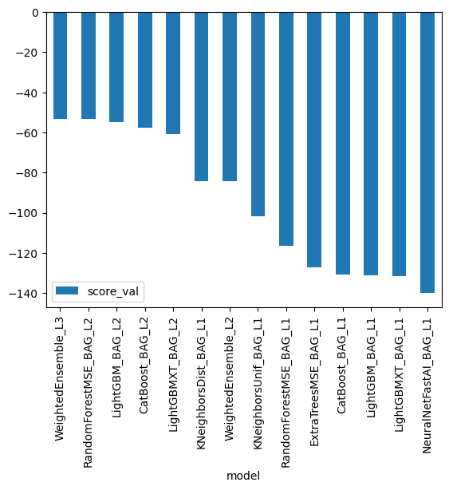

```python
display(predictor.evaluate(train))
#Plot the comparative performance
predictor.leaderboard(silent=True).plot(kind="bar", x="model", y="score_val")
```

```python
#test=test.sample(frac=1)
predictions = predictor.predict(test)
predictions.head()
```

```
0    23.201000
1    43.250420
2    46.797245
3    50.148552
4    52.006027
Name: count, dtype: float32
```

#### NOTE: Kaggle will reject the submission if we don't set everything to be > 0.

```python
# Describe the `predictions` series to see if there are any negative values
print("lowest value: {}".format(predictions.describe().min()))
```

```
lowest value: 3.0698976516723633
```

```python
# How many negative values do we have?
print("number of negatives: {}".format(predictions[predictions[predictions<0]].count()))
```

```
number of negatives: 0
```

```python
# Set them to zero
predictions[predictions<0] = 0
print("number of negatives: {}".format(predictions[predictions[predictions<0]].count()))
```

```
number of negatives: 0
```

### Set predictions to submission dataframe, save, and submit

```python
submission["count"] = predictions
submission.to_csv("submission.csv", index=False)
```

```python
!kaggle competitions submit -c bike-sharing-demand -f submission.csv -m "first raw submission"
```

```
Successfully submitted to Bike Sharing Demand
```

```
 49%|####9     | 96.0k/195k [00:00<00:00, 849kB/s]
```

#### View submission via the command line or in the web browser under the competition's page - `My Submissions`

```python
!kaggle competitions submissions -c bike-sharing-demand
```

```
fileName                     date                        description                        status                     publicScore  privateScore
---------------------------  --------------------------  ---------------------------------  -------------------------  -----------  ------------
submission.csv               2025-03-17 23:01:38.600000  first raw submission               SubmissionStatus.COMPLETE  1.79825      1.79825
submission_new_hpo.csv       2025-03-17 19:20:04.947000  new features with hyperparameters  SubmissionStatus.COMPLETE  0.58342      0.58342
submission_new_features.csv  2025-03-17 19:03:44.257000  new features                       SubmissionStatus.COMPLETE  0.62238      0.62238
submission.csv               2025-03-17 18:40:52.423000  first raw submission               SubmissionStatus.COMPLETE  1.74836      1.74836
submission_new_hpo.csv       2025-03-16 20:38:41.363000  new features with hyperparameters  SubmissionStatus.COMPLETE  0.54933      0.54933
submission_new_features.csv  2025-03-16 15:46:17.070000  new features                       SubmissionStatus.COMPLETE  0.71084      0.71084
submission.csv               2025-03-15 20:49:53.433000  first raw submission               SubmissionStatus.COMPLETE  1.78224      1.78224
submission.csv               2025-03-15 20:32:09.947000  first raw submission               SubmissionStatus.COMPLETE  1.79968      1.79968
```

## Step 4: Exploratory Data Analysis and Creating an additional feature

- Any additional feature will do, but a great suggestion would be to separate out the datetime into hour, day, or month parts.

```
array([[<Axes: title={'center': 'season'}>,
        <Axes: title={'center': 'holiday'}>,
        <Axes: title={'center': 'workingday'}>],
       [<Axes: title={'center': 'weather'}>,
        <Axes: title={'center': 'temp'}>,
        <Axes: title={'center': 'atemp'}>],
       [<Axes: title={'center': 'humidity'}>,
        <Axes: title={'center': 'windspeed'}>,
        <Axes: title={'center': 'count'}>]], dtype=object)
```

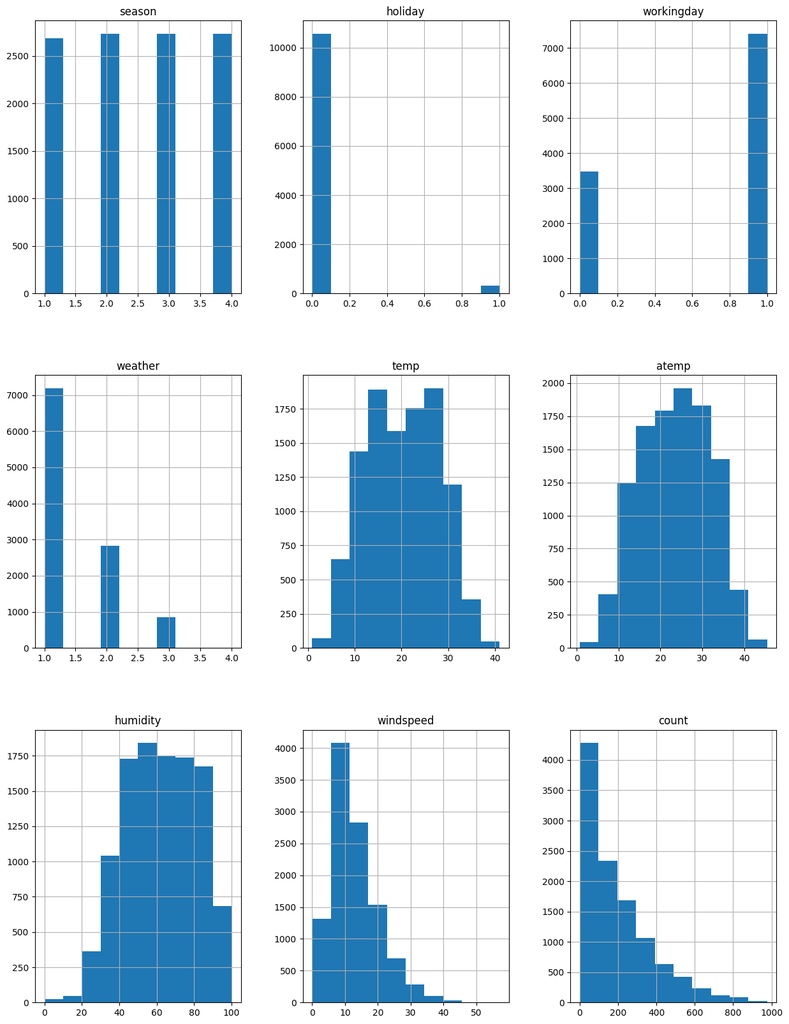

```python
# Create a histogram of all features to show the distribution of each one relative to the data. This is part of the exploritory data analysis.
train.hist(figsize=(15,20))
```

```python
train.info()
```

```
<class 'pandas.core.frame.DataFrame'>
RangeIndex: 10886 entries, 0 to 10885
Data columns (total 10 columns):
 #   Column      Non-Null Count  Dtype
---  ------      --------------  -----
 0   datetime    10886 non-null  object
 1   season      10886 non-null  int64
 2   holiday     10886 non-null  int64
 3   workingday  10886 non-null  int64
 4   weather     10886 non-null  int64
 5   temp        10886 non-null  float64
 6   atemp       10886 non-null  float64
 7   humidity    10886 non-null  int64
 8   windspeed   10886 non-null  float64
 9   count       10886 non-null  int64
dtypes: float64(3), int64(6), object(1)
memory usage: 850.6+ KB
```

```python
# create a new feature
train['datetime'] = pd.to_datetime(train['datetime'], errors='coerce')
train["hour"] = train["datetime"].dt.hour
train["month"] = train["datetime"].dt.month
train["day"] = train["datetime"].dt.day
#train.drop('year', axis = 1, inplace = True)

test['datetime'] = pd.to_datetime(test['datetime'], errors='coerce')
test["hour"] = test["datetime"].dt.hour
test["month"] = test["datetime"].dt.month
test["day"] = test["datetime"].dt.day
```

## Make category types for these so models know they are not just numbers

- AutoGluon originally sees these as ints, but in reality they are int representations of a category.
- Setting the dtype to category will classify these as categories in AutoGluon.

```python
train["season"] = train["season"].astype(str)
train["weather"] = train["weather"].astype(str)
test["season"] = test["season"].astype(str)
test["weather"] = test["season"].astype(str)
train.info()
```

```
<class 'pandas.core.frame.DataFrame'>
RangeIndex: 10886 entries, 0 to 10885
Data columns (total 13 columns):
 #   Column      Non-Null Count  Dtype
---  ------      --------------  -----
 0   datetime    10886 non-null  datetime64[ns]
 1   season      10886 non-null  object
 2   holiday     10886 non-null  int64
 3   workingday  10886 non-null  int64
 4   weather     10886 non-null  object
 5   temp        10886 non-null  float64
 6   atemp       10886 non-null  float64
 7   humidity    10886 non-null  int64
 8   windspeed   10886 non-null  float64
 9   count       10886 non-null  int64
 10  hour        10886 non-null  int32
 11  month       10886 non-null  int32
 12  day         10886 non-null  int32
dtypes: datetime64[ns](1), float64(3), int32(3), int64(4), object(2)
memory usage: 978.2+ KB
```

```python
# View are new feature
train.head()
```

|  | datetime | season | holiday | workingday | weather | temp | atemp | humidity | windspeed | count | hour | month | day |
| --- | --- | --- | --- | --- | --- | --- | --- | --- | --- | --- | --- | --- | --- |
| 0 | 2011-01-01 00:00:00 | 1 | 0 | 0 | 1 | 9.84 | 14.395 | 81 | 0.0 | 16 | 0 | 1 | 1 |
| 1 | 2011-01-01 01:00:00 | 1 | 0 | 0 | 1 | 9.02 | 13.635 | 80 | 0.0 | 40 | 1 | 1 | 1 |
| 2 | 2011-01-01 02:00:00 | 1 | 0 | 0 | 1 | 9.02 | 13.635 | 80 | 0.0 | 32 | 2 | 1 | 1 |
| 3 | 2011-01-01 03:00:00 | 1 | 0 | 0 | 1 | 9.84 | 14.395 | 75 | 0.0 | 13 | 3 | 1 | 1 |
| 4 | 2011-01-01 04:00:00 | 1 | 0 | 0 | 1 | 9.84 | 14.395 | 75 | 0.0 | 1 | 4 | 1 | 1 |

```
array([[<Axes: title={'center': 'datetime'}>,
        <Axes: title={'center': 'holiday'}>,
        <Axes: title={'center': 'workingday'}>],
       [<Axes: title={'center': 'temp'}>,
        <Axes: title={'center': 'atemp'}>,
        <Axes: title={'center': 'humidity'}>],
       [<Axes: title={'center': 'windspeed'}>,
        <Axes: title={'center': 'count'}>,
        <Axes: title={'center': 'hour'}>],
       [<Axes: title={'center': 'month'}>,
        <Axes: title={'center': 'day'}>, <Axes: >]], dtype=object)
```

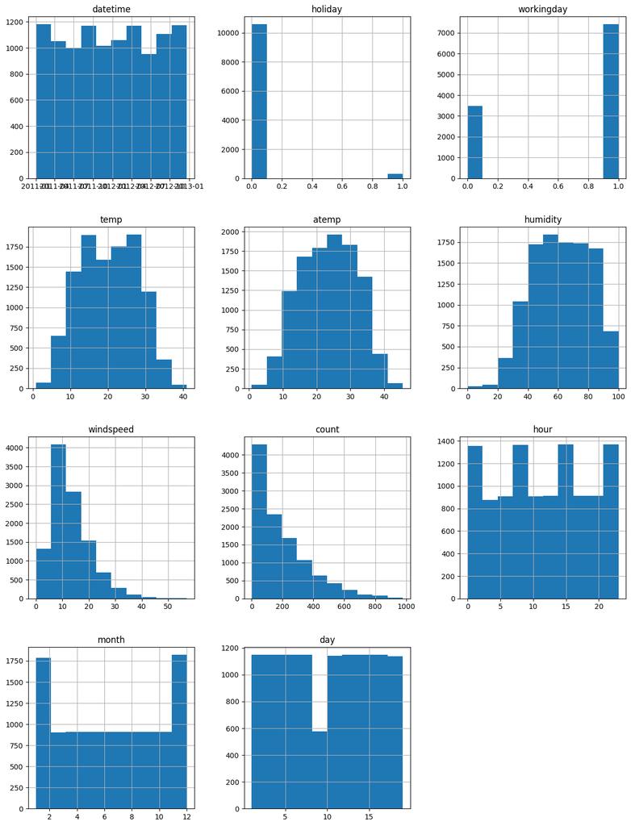

```python
# View histogram of all features again now with the hour feature
train.hist(figsize=(15,20))
```

## Step 5: Rerun the model with the same settings as before, just with more features

```python
#predictor_new_features = TabularPredictor(?).fit(?)

predictor_new_features = TabularPredictor(label="count", problem_type='regression',
                             eval_metric = 'root_mean_squared_error',learner_kwargs={"ignored_columns": ["datetime"]}).fit(train_data=train.sample(frac=1),
                                                                                                                           time_limit=600, presets="best_quality"
                                                                                                                   )
```

[output not shown]

[output cut: 103 more lines]

```
	-49.9966	 = Validation score   (-root_mean_squared_error)
	22.59s	 = Training   runtime
	1.58s	 = Validation runtime
Fitting model: CatBoost_BAG_L2 ... Training model for up to 64.71s of the 64.56s of remaining time.
	Fitting 8 child models (S1F1 - S1F8) | Fitting with ParallelLocalFoldFittingStrategy (8 workers, per: cpus=1, gpus=0, memory=0.46%)
	-50.1306	 = Validation score   (-root_mean_squared_error)
	52.52s	 = Training   runtime
	0.35s	 = Validation runtime
Fitting model: WeightedEnsemble_L3 ... Training model for up to 360.00s of the 3.67s of remaining time.
	Ensemble Weights: {'RandomForestMSE_BAG_L2': 0.435, 'LightGBM_BAG_L2': 0.217, 'CatBoost_BAG_L2': 0.217, 'LightGBMXT_BAG_L1': 0.087, 'LightGBM_BAG_L1': 0.043}
	-49.477	 = Validation score   (-root_mean_squared_error)
	0.11s	 = Training   runtime
	0.0s	 = Validation runtime
AutoGluon training complete, total runtime = 426.72s ... Best model: WeightedEnsemble_L3 | Estimated inference throughput: 15.0 rows/s (1361 batch size)
TabularPredictor saved. To load, use: predictor = TabularPredictor.load("C:\Python\projects\cd0385-project-starter\project\AutogluonModels\ag-20250317_231334")
```

```python
predictor_new_features.fit_summary()
```

[output not shown]

[output not shown]

[output cut: 127 more lines]

```

     stack_level  can_infer  fit_order
 0             3       True         13
 1             2       True         11
 2             2       True         12
 3             2       True          9
 4             2       True         10
 5             1       True          3
 6             1       True          4
 7             1       True          6
 8             1       True          7
 9             1       True          5
 10            1       True          2
 11            1       True          1
 12            1       True          8  }
```

```
{'root_mean_squared_error': -22.01820973032995,
 'mean_squared_error': -484.80155972879646,
 'mean_absolute_error': -13.68739788580002,
 'r2': 0.9852241277694702,
 'pearsonr': 0.9926526170991522,
 'median_absolute_error': -7.843394756317139}
```

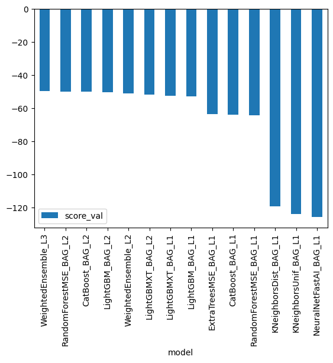

```python
display(predictor_new_features.evaluate(train))
#Plot the comparative performance
predictor_new_features.leaderboard(silent=True).plot(kind="bar", x="model", y="score_val")
```

```python
predictions_new_features = predictor_new_features.predict(test.iloc[:, test.columns != 'datetime'])
predictions.head()
```

```
0    23.201000
1    43.250420
2    46.797245
3    50.148552
4    52.006027
Name: count, dtype: float32
```

```python
# Remember to set all negative values to zero
print("lowest value: {}".format(predictions_new_features.describe().min()))
print("number of negatives: {}".format(predictions_new_features[predictions_new_features<0].count()))
```

```
lowest value: -0.07433700561523438
number of negatives: 1
```

```python
predictions_new_features[predictions_new_features<0] = 0
print("number of negatives: {}".format(predictions_new_features[predictions_new_features<0].count()))
```

```
number of negatives: 0
```

```python
# Same submitting predictions
submission_new_features = pd.read_csv('./bike-sharing-demand/sampleSubmission.csv')
submission_new_features["count"] = predictions_new_features
submission_new_features.to_csv("submission_new_features.csv", index=False)
submission_new_features.head()
```

|  | datetime | count |
| --- | --- | --- |
| 0 | 2011-01-20 00:00:00 | 31.468889 |
| 1 | 2011-01-20 01:00:00 | 7.556555 |
| 2 | 2011-01-20 02:00:00 | 5.461270 |
| 3 | 2011-01-20 03:00:00 | 5.113492 |
| 4 | 2011-01-20 04:00:00 | 5.125060 |

```python
!kaggle competitions submit -c bike-sharing-demand -f submission_new_features.csv -m "new features"
```

```
Successfully submitted to Bike Sharing Demand
```

```
  8%|8         | 16.0k/194k [00:00<00:01, 158kB/s]
```

```python
!kaggle competitions submissions -c bike-sharing-demand | tail -n +1 | head -n 6
```

[output not shown]

## Step 6: Hyper parameter optimization

- There are many options for hyper parameter optimization.
- Options are to change the AutoGluon higher level parameters or the individual model hyperparameters.
- The hyperparameters of the models themselves that are in AutoGluon. Those need the `hyperparameter` and `hyperparameter_tune_kwargs` arguments.

```python
#predictor_new_hpo = TabularPredictor(?).fit(?)

# LightGBM:
gbm_options = {
    'num_boost_round': 100,  # Number of boosting rounds
    'num_leaves': ag.common.space.Int(lower=26, upper=66, default=36)  # Number of leaves in trees
}

# Neural Networks:
nn_options = {
    'num_epochs': ag.common.space.Int(lower=10, upper=50, default=20),  # Number of epochs
    'learning_rate': ag.common.space.Real(0.0, 0.5, default=0.1)  # Learning rate
}

hyperparameters = {
    'GBM': gbm_options,
    'NN_TORCH': nn_options,
    'CAT': {'iterations': 10000},
    'RF': {'n_estimators': 300},
    'XT': {'n_estimators': 300}}

hyperparameter_tune_kwargs={'num_trials': 50, 'searcher': 'auto', 'scheduler': 'local'}

predictor_new_hpo = TabularPredictor(label="count", problem_type='regression', learner_kwargs={"ignored_columns": ["datetime"]},
                             eval_metric = 'root_mean_squared_error').fit(train_data=train,
                                                                          presets="best_quality",
                                                                          time_limit=700,
                                                                          hyperparameters = hyperparameters,
                                                                          hyperparameter_tune_kwargs=hyperparameter_tune_kwargs)
```

[output not shown]

```python
predictor_new_hpo.fit_summary()
```

[output not shown]

[output not shown]

[output cut: 317 more lines]

```
 13            1       True          1
 14            1       True         13
 15            1       True          5
 16            1       True         14
 17            1       True         11
 18            2       True         24
 19            2       True         22
 20            1       True          9
 21            1       True          6
 22            1       True         15
 23            1       True          4
 24            1       True         12
 25            1       True         16
 26            2       True         27
 27            1       True         17  }
```

```
{'root_mean_squared_error': -34.98020169420488,
 'mean_squared_error': -1223.6145105672538,
 'mean_absolute_error': -22.28837352739238,
 'r2': 0.9627063870429993,
 'pearsonr': 0.981436211268512,
 'median_absolute_error': -12.84896469116211}
```

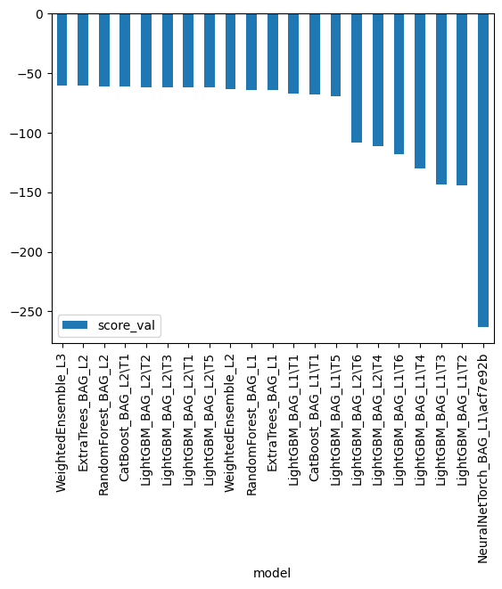

```python
display(predictor_new_hpo.evaluate(train))
#Plot the comparative performance
predictor_new_hpo.leaderboard(silent=True).plot(kind="bar", x="model", y="score_val")
```

```python
# Prediction on test data:
predictions_new_hpo = predictor_new_hpo.predict(test.iloc[:, test.columns != 'datetime'])
predictions_new_hpo.head()
```

```
0    13.452458
1     7.957891
2     5.681105
3     4.087816
4     4.174010
Name: count, dtype: float32
```

```python
# Remember to set all negative values to zero
print("lowest value: {}".format(predictions_new_hpo.describe().min()))
print("number of negatives: {}".format(predictions_new_hpo[predictions_new_features<0].count()))
```

```
lowest value: 2.938952922821045
number of negatives: 0
```

```python
predictions_new_hpo[predictions_new_hpo<0] = 0
print("number of negatives: {}".format(predictions_new_hpo[predictions_new_hpo<0].count()))
```

```
number of negatives: 0
```

```python
# Same submitting predictions
submission_new_hpo = pd.read_csv('./bike-sharing-demand/sampleSubmission.csv')
submission_new_hpo["count"] = predictions_new_hpo
submission_new_hpo.to_csv("submission_new_hpo.csv", index=False)
submission_new_features.head()
```

|  | datetime | count |
| --- | --- | --- |
| 0 | 2011-01-20 00:00:00 | 31.468889 |
| 1 | 2011-01-20 01:00:00 | 7.556555 |
| 2 | 2011-01-20 02:00:00 | 5.461270 |
| 3 | 2011-01-20 03:00:00 | 5.113492 |
| 4 | 2011-01-20 04:00:00 | 5.125060 |

```python
!kaggle competitions submit -c bike-sharing-demand -f submission_new_hpo.csv -m "new features with hyperparameters"
```

```
Successfully submitted to Bike Sharing Demand
```

```
 58%|#####7    | 112k/195k [00:00<00:00, 925kB/s]
```

```python
!kaggle competitions submissions -c bike-sharing-demand #| tail -n +1 | head -n 6
```

```
fileName                     date                        description                        status                     publicScore  privateScore
---------------------------  --------------------------  ---------------------------------  -------------------------  -----------  ------------
submission_new_hpo.csv       2025-03-18 21:39:14.877000  new features with hyperparameters  SubmissionStatus.COMPLETE  0.53777      0.53777
submission_new_hpo.csv       2025-03-18 00:03:30.613000  new features with hyperparameters  SubmissionStatus.COMPLETE  0.58115      0.58115
submission.csv               2025-03-17 23:01:38.600000  first raw submission               SubmissionStatus.COMPLETE  1.79825      1.79825
submission_new_hpo.csv       2025-03-17 19:20:04.947000  new features with hyperparameters  SubmissionStatus.COMPLETE  0.58342      0.58342
submission_new_features.csv  2025-03-17 19:03:44.257000  new features                       SubmissionStatus.COMPLETE  0.62238      0.62238
submission.csv               2025-03-17 18:40:52.423000  first raw submission               SubmissionStatus.COMPLETE  1.74836      1.74836
submission_new_hpo.csv       2025-03-16 20:38:41.363000  new features with hyperparameters  SubmissionStatus.COMPLETE  0.54933      0.54933
submission_new_features.csv  2025-03-16 15:46:17.070000  new features                       SubmissionStatus.COMPLETE  0.71084      0.71084
submission.csv               2025-03-15 20:49:53.433000  first raw submission               SubmissionStatus.COMPLETE  1.78224      1.78224
submission.csv               2025-03-15 20:32:09.947000  first raw submission               SubmissionStatus.COMPLETE  1.79968      1.79968
```